# HomeWork_1

Sai Pradeep C S

November 2, 2015

Q1. Import the CSV file ‘FAA_r.csv’ using the function “read.table()” or “read.csv()”. Where to find the instruction on how to use the functions?

Solution: To import the datafile we can either use read.csv() or read.table(). It depends on format of data. If the data is comma separated, we use read.csv(). We can find more on how to use these functions by typing *?read.csv* or *?read.table* in the console

```r
flights <- read.table('D:/ACADS/Data Analysis and Methods/FAA_r.csv',header=TRUE,sep = ',')
flights
```

```
##       type   duration no_psng speed_ground speed_air    height    pitch
## 1   Airbus 121.262420      58     85.29936        NA 26.588809 3.648814
## 2   Boeing 152.251622      68     73.19322        NA 14.405106 3.894732
## 3   Airbus 131.070965      45    112.14822 110.76828 18.116866 4.008138
## 4   Boeing 272.553379      69     57.10247        NA 44.539825 4.027583
## 5   Airbus 167.782365      66     80.33115        NA 37.945091 4.325113
## 6   Boeing 218.211910      60     84.57876        NA 25.198880 3.785255
## 7   Airbus 155.959625      64     63.84329        NA 34.818636 3.826498
## 8   Boeing  73.746066      64     79.36281        NA 35.982995 3.945258
## 9   Airbus 208.550476      64    117.88536 117.64601 17.395917 4.030789
## 10  Airbus 219.987762      65     73.67062        NA 44.829519 4.439555
## 11  Boeing 178.908769      54     58.80125        NA 24.829063 3.976442
## 12  Boeing 181.231603      62     69.26535        NA 40.587734 4.718040
## 13  Airbus  51.710057      58     73.55588        NA 33.227541 3.943867
## 14  Airbus 194.794037      82     98.49597  97.24624 13.866170 2.937598
```

[output cut: 786 more lines]

Q2. How many variables in the data set? What are their names?

Solution: Length function is used to print the number of variables in the data frame and names function is used to print the column names of the dataframe. Type **?length** and **?name** in consoel to understand on how to use these functions

```r
length(names(flights))
```

```
## [1] 7
```

```r
names <-names(flights)
names
```

```
## [1] "type"         "duration"     "no_psng"      "speed_ground"
## [5] "speed_air"    "height"       "pitch"
```

Q3. How many observations in total? How many observations for Airbus?

Solution: Length function can be used to count the number of observations

```r
Airbus<-length(which(flights$type=="Airbus"))
Airbus
```

```
## [1] 400
```

Q4. Calculate the mean for each of the flight parameters (measures). Please also report the corresponding standard deviation.

Solution: We can use **colMeans** to find the mean for all columns at once of a data frame and also **apply** function with **sd** as a parameter on columns can be used to find **Standard deviation** on all columns in a data frame. Type *?colMeans* and *?apply* in console to understand how to use these functions

```r
subflights<-flights[c(2:7)]
colMeans(subflights,na.rm = TRUE,dims = 1)
```

```
##     duration      no_psng speed_ground    speed_air       height
##   149.174041    60.040000    79.357758   102.037920    29.759491
##        pitch
##     4.170417
```

```r
apply(subflights, 2,sd,na.rm = TRUE)
```

```
##     duration      no_psng speed_ground    speed_air       height
##    50.386488     7.840615    20.190638    10.325295    10.046443
##        pitch
##     0.494420
```

Q5. Obtain the histogram for each of the flight parameters.

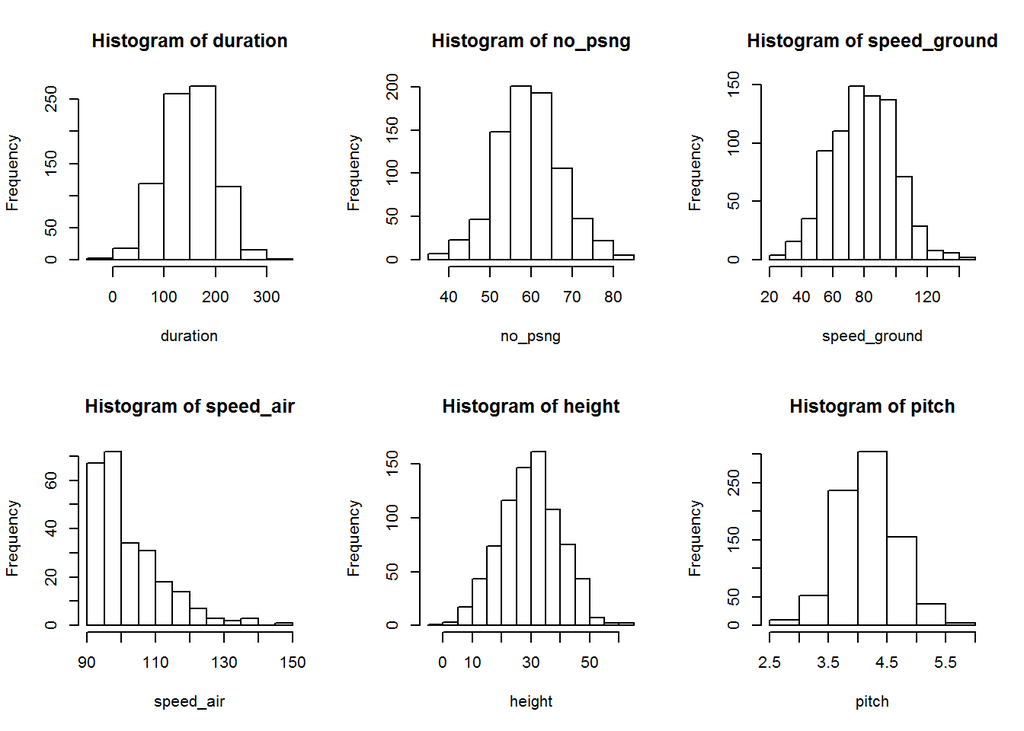

```r
par(mfrow=c(2,3))

for(i in 1:length(subflights))
  {
  main<-paste("Histogram of", names[i+1])
  xLabel <- paste(names[i+1])
  hist(subflights[,i],xlab = xLabel,main = main)

 }
```

Q6. Is there any missing value in the data set? If yes, which variable? What is the proportion of missing values? By exploring the data, can you see the pattern of missing values? In other words, when the values are missing?

Solution: From Analysis it is observed that When **speed_ground** is less than 87 (approxiamtely) **speed_air** value is NA

```r
#Total NA in flights$speed_air

apply(is.na(flights),2,sum)
```

```
##         type     duration      no_psng speed_ground    speed_air
##            0            0            0            0          548
##       height        pitch
##            0            0
```

```r
#Total non NA in flights$speed_air

apply(!(is.na(flights)),2,sum)
```

```
##         type     duration      no_psng speed_ground    speed_air
##          800          800          800          800          252
##       height        pitch
##          800          800
```

```r
proportion <- apply(is.na(flights),2,sum)[5]/apply(!(is.na(flights)),2,sum)[1]
print(proportion)
```

```
## speed_air
##     0.685
```

```r
NA_speed_air <- flights[which(flights$speed_ground<87),]
print(NA_speed_air)
```

```
##       type   duration no_psng speed_ground speed_air    height    pitch
## 1   Airbus 121.262420      58     85.29936        NA 26.588809 3.648814
## 2   Boeing 152.251622      68     73.19322        NA 14.405106 3.894732
## 4   Boeing 272.553379      69     57.10247        NA 44.539825 4.027583
## 5   Airbus 167.782365      66     80.33115        NA 37.945091 4.325113
## 6   Boeing 218.211910      60     84.57876        NA 25.198880 3.785255
## 7   Airbus 155.959625      64     63.84329        NA 34.818636 3.826498
## 8   Boeing  73.746066      64     79.36281        NA 35.982995 3.945258
## 10  Airbus 219.987762      65     73.67062        NA 44.829519 4.439555
## 11  Boeing 178.908769      54     58.80125        NA 24.829063 3.976442
## 12  Boeing 181.231603      62     69.26535        NA 40.587734 4.718040
## 13  Airbus  51.710057      58     73.55588        NA 33.227541 3.943867
## 15  Boeing  41.252256      52     55.24772        NA 29.813775 4.008848
## 16  Boeing 138.871601      45     53.04263        NA 40.535433 4.687860
## 18  Boeing  80.988035      52     33.97510        NA 29.321915 4.767940
```

[output cut: 491 more lines]

```r
dim(NA_speed_air)
```

```
## [1] 505   7
```

Q7. Calculate the speed of the air flow (defined as the difference between speed_ground and speed_air). What is the average speed of the air flow? Note the speed should be positive.

Solution: As speed should be positive, individual values in speed_airflow should be positive too. In order make speed positive we can take absolute of **speed_airflow** and find mean of **speed_airflow** by omitting NA values (Type ?abs and ?mean in console to understand how to use these functions)

```r
flights$speed_airflow <- (flights$speed_air - flights$speed_ground)
Average_Speed_airflow<-mean(abs(flights$speed_airflow),na.rm = TRUE)
Average_Speed_airflow
```

```
## [1] 1.135942
```

Q8. How many flights have duration less than 40 minutes? How many flights have height less than 6 meters? Please delete those observations from the data set.

Solution: We can use **sum** function to count the number of records satisfying certain criteria (duration<40 and height<6 in our case)

```r
sum(flights$duration<40)
```

```
## [1] 9
```

```r
sum(flights$height<6)
```

```
## [1] 6
```

```r
flights <- flights[-c(c(which(flights$height<6)),which(flights$duration<40)),]
dim(flights)
```

```
## [1] 785   8
```

Q9. Divide the cleaned data set (as obtained in Step 8) into two subsets: Airbus and Boeing.

```r
flights_airbus <- flights[which(flights$type=="Airbus"),]
flights_Boeing <- flights[which(flights$type=="Boeing"),]
```

Q10. Is there any difference between these two aircraft makes (in terms of speed, height, pitch)?

Solution: Mean speed_ground of Airbus and Boeing are 79.86 and 78.80

Mean speed_air of Airbus and Boeing are 102.37 and 101.83

Mean height of Airbus and Boeing are 29.65 and 30.287

Mean pitch of Airbus and Boeing are 4.177 and 4.164

**From the above observation, there is no major difference between these two aircraft makes**

```r
summary(flights_airbus)[c(1,3,4,6),c(4,5,6,7)]
```

```
##   speed_ground        speed_air            height            pitch
##  "Min.   : 26.64  " "Min.   : 90.17  " "Min.   : 6.20  " "Min.   :2.700  "
##  "Median : 79.56  " "Median : 98.97  " "Median :29.74  " "Median :4.146  "
##  "Mean   : 79.86  " "Mean   :102.37  " "Mean   :29.65  " "Mean   :4.177  "
##  "Max.   :149.42  " "Max.   :148.73  " "Max.   :61.21  " "Max.   :5.911  "
```

```r
summary(flights_Boeing)[c(1,3,4,6),c(4,5,6,7)]
```

```
##   speed_ground        speed_air            height
##  "Min.   : 23.40  " "Min.   : 90.13  " "Min.   : 6.306  "
##  "Median : 79.57  " "Median : 98.02  " "Median :30.353  "
##  "Mean   : 78.80  " "Mean   :101.83  " "Mean   :30.287  "
##  "Max.   :142.55  " "Max.   :139.67  " "Max.   :58.696  "
##      pitch
##  "Min.   :2.654  "
##  "Median :4.162  "
##  "Mean   :4.164  "
##  "Max.   :5.537  "
```